# 机器学习与因果推断 - 第十二讲：前沿专题——因果推断与 AI，大语言模型的应用

从 vibe coding 到可复现 research workflow：完整讲义

作者

单位

陈志远

中国人民大学商学院

发布于

2026年6月9日

# 1 引言

经过一整个学期，我们已经从潜在结果框架、DAG、匹配法、工具变量、双重差分一路走到因果森林与双重机器学习。到这里，大家已经掌握了相当完整的因果推断工具箱，也知道在高维控制和异质性分析中，机器学习如何真正进入因果研究。

但真正的研究工作并不只是在最后一步跑一个估计工具。研究者还需要决定：问题如何定义、变量如何组织、数据如何清洗、识别策略是否可信、结果该如何解释、反对意见如何回应、最终报告如何组织。*换言之，估计工具只是 workflow 中的一个环节，而不是全部。*

因此，这一讲更像课程收官时的一次方法论升级：把 AI 放回到完整的 research workflow 里来理解，看看在 AI 时代，研究者应如何更高效地与工具协作，同时保持识别、验证与复现的严谨性。

**注记本讲核心观点**

AI 不是识别策略的替代品，也不是因果结论的自动生成器。它的真正价值在于：作为研究 workflow 的协作者，帮助我们更快地分解问题、组织数据、搭建脚手架、审查结果，并把分析沉淀成可复现资产。

## 1.1 本讲目标

完成本讲后，你应能够：

1. 区分 AI 在因果研究中的高价值用途与高风险误用
2. 把一个因果问题拆解成被估量（estimand）、识别假设、数据审计与估计流程
3. 使用大语言模型协助搭建本地可运行的分析脚手架
4. 理解“严谨版 vibe coding”的基本原则
5. 设计一套包含验证、日志与回滚机制的 AI 协作研究 workflow

## 1.2 学期回顾

到本讲为止，本课程已经形成了一个从经典识别到现代工具的完整链条。最值得保留的四条主线是：

- **潜在结果分析框架**：经典因果推断的理论基础
- **DAG**：识别假设与偏误路径的可视化工具
- **机器学习基本工具**：回归、决策树、随机森林、交叉验证
- **因果机器学习与异质性处理效应**：因果森林与双重机器学习

这些内容共同回答了一个学期的核心目标：我们不只是在学“怎么跑一个回归”，而是在学如何从数据中提出并回答“为什么”的问题。现在课程进入收束阶段，最终的问题就变成了：在已经掌握这些工具之后，如何把 AI 纳入完整研究流程，同时不牺牲识别、验证与复现？

# 2 第一部分：AI 不是识别策略的替代品

## 2.1 为什么在课程收官讲 AI workflow

许多同学第一次接触 AI 时，会自然地产生两个误解：

1. 既然大语言模型会写代码，那以后研究是不是只要会提问就够了？
2. 既然大模型知道很多论文和案例，它是不是也能自动判断识别是否可信？

这两种看法都不成立。第一种忽略了研究中最难的部分不是“写代码”，而是“提出正确问题并判断证据是否充分”。第二种则把语言模型的模式匹配能力误解成了识别能力。

**警告边界必须先讲清楚**

识别来自研究设计、时间顺序、制度背景和可辩护的假设；不会因为提示词写得漂亮就自动成立。

因此，这一讲不是在说“AI 会替代因果推断”，而是在说“当我们已经掌握一套因果推断工具之后，如何把 AI 变成高效且受控的研究协作者”。

## 2.2 AI 在因果研究中的合理位置

把完整研究流程拆开来看，AI 的角色其实非常清晰：

| 研究环节 | AI 的合理角色 | 研究者的核心责任 |
| --- | --- | --- |
| **问题定义** | 帮助提炼 estimand、梳理变量、生成候选路径 | 确认问题是否具有因果含义 |
| **识别设计** | 列出假设、给出反例、画出 DAG 草图 | 判断假设是否在现实中成立 |
| **数据工作** | 生成探索性数据分析（Explorative Data Analysis, EDA）、清洗、特征工程与文本结构化脚手架 | 审核口径、时间顺序、样本边界 |
| **估计推断** | 组织 DML、因果森林、稳健性模板 | 审查模型与解释边界 |
| **写作表达** | 生成图注、摘要、审稿清单、问答稿 | 对结论、措辞和声誉负责 |

从这个表格可以看出，AI 最强的是 *组织与加速*，而不是 *承担责任*。

## 2.3 什么是“严谨版 vibe coding”

在软件圈，“vibe coding”往往指用自然语言快速驱动代码生成。但在学术研究和数据分析场景里，这个词如果不加限定，就容易滑向一种危险做法：让 AI 连续不断地产出代码，而研究者既不验证，也不记录。

更合理的定义是：

**注记严谨版 vibe coding**

使用自然语言加速原型开发，但必须同时满足四个条件：结构化输入、局部验证、可回滚、可审计。

这意味着：

- 你给 AI 的不是一句模糊要求，而是变量字典、样本限制、目标参数和验证要求
- AI 生成的不是“终局结论”，而是可以单独运行、单独检查的模块
- 你始终保留修改、删除、回退和重写的权力
- 每次重要更改都要进入日志或版本控制

## 2.4 一个常见反例

假设学生告诉 AI：

> “帮我估计补贴对留存的因果效应，控制所有相关变量。”

一个看似“聪明”的模型，可能会把“补贴后的曝光量”“补贴后的点击率”“补贴后的活跃度”统统列进控制变量集合。这样生成的代码甚至可以顺利跑完，但识别已经彻底被破坏了，因为这些变量发生在处理之后，属于 post-treatment variables。

这里暴露出研究中最重要的区分：

- **AI 能列出候选变量**
- **研究者必须判断变量与处理的时间关系、机制关系和可控制性**

因此，本讲后面每一个 AI 应用场景，都会同时回答四个问题：

1. 它替代了哪一步劳动？
2. 它可能犯什么错？
3. 我如何验证？
4. 失败之后如何回退？

# 3 第二部分：AI 辅助的因果分析工作流

## 3.1 从研究问题到被估量（estimand）

因果研究的第一步永远不是打开 Python，而是明确“我要估计什么”。AI 在这里最有价值的用途，是帮助研究者把模糊问题拆成一个可分析对象。

例如，原始问题可能是：

> “平台给商家发券，到底能不能提高长期留存概率？”

一个更好的结构化表达应当包含：

- **处理变量**：是否收到定向优惠券
- **结果变量**：30 天后是否继续活跃
- **估计对象**：ATE、ATT，还是特定子群的 CATE
- **候选混杂**：历史销量、地区、店铺年龄、平台评级、行业固定效应
- **主要识别风险**：平台可能会把券定向发给更有增长潜力的商家

这一步完全可以让 AI 辅助完成，但前提是你提供足够上下文，并要求它输出结构化结果，而不是直接给一个“结论”。

### 3.1.1 一个推荐的提示模板

```
Prompt: 请把下面的研究问题拆解成因果分析输入，不要直接做结论：
1. 处理变量
2. 结果变量
3. 目标 estimand
4. 候选混杂变量
5. 不能控制的 post-treatment variables
6. 需要人工核对的识别风险

研究问题：平台补贴是否提升商家 30 天留存？
```

这个模板的关键不是“让 AI 显得更聪明”，而是强迫它按照研究者能检查的维度输出内容。

## 3.2 DAG、假设与样本限制

在把问题拆开之后，下一步应是识别审查。这一步特别适合采用“AI 提草图，人来裁决”的模式。

你可以让 AI 做三件事：

1. 列出后门路径与潜在混杂
2. 提醒可能的样本选择问题
3. 给出需要画进 DAG 的变量清单

但最后真正要由研究者负责的，是：

- 某变量是否发生在处理之前
- 某路径是否是实际制度过程的一部分
- 某样本限制是否会引入新的偏差

换言之，AI 可以帮助你“想全”，但不能替你“想对”。

## 3.3 数据审计：AI 先搭框架，人来定口径

在许多项目里，最容易被低估的一步是数据审计。研究失败往往不是因为没有更复杂的估计器，而是因为：

- 变量定义混乱
- 时间顺序没对齐
- 样本口径中途变化
- 文本字段和结构化字段没有打通

AI 很适合在这里产出初始 schema summary、缺失表、异常值清单、EDA 模板，但所有这些内容都必须经过人工审核。

**提示一个实用原则**

先让 AI 告诉你“应该看什么”，再由你决定“什么值得信”。

### 3.3.1 Python 演示：小样本数据审计

```python
print(pilot_df.to_string(index=False))
print()
print(audit_summary.to_string(index=False))
```

```
 merchant_id  coupon_exposure  retention_30d  age_days  prior_sales region        note
         101                1              1     180.0         5200   East 政策稳定，补贴响应积极
         102                0              0      23.0          320   West     样本刚入驻平台
         103                1              1     400.0         8100   East  品牌商家，历史销量高
         104                1              1      52.0         1100  North        None
         105                0              0      90.0          900   West      季节波动明显
         106                1              1       NaN         4300  South  渠道调整导致口径变化

             变量  缺失个数  缺失率  唯一值个数
    merchant_id     0 0.00      6
coupon_exposure     0 0.00      2
  retention_30d     0 0.00      2
       age_days     1 0.17      5
    prior_sales     0 0.00      6
         region     0 0.00      4
           note     1 0.17      5
```

这段输出虽然简单，但已经足够说明三件事：

1. `age_days` 与 `note` 存在缺失
2. `region` 是分类变量，编码与聚合方式会影响后续估计
3. 文本字段 `note` 可能包含重要制度信息，但不能直接进回归，需要先结构化

### 3.3.2 这一环节适合交给 AI 的具体任务

- 生成缺失值、唯一值、异常值检查代码
- 生成数据字典草稿
- 生成样本限制 checklist
- 生成图表标题、变量翻译和初步注释

### 3.3.3 不应直接外包的判断

- 缺失是否随机
- 某字段是否是 post-treatment measure
- 样本剔除是否改变了研究对象
- 文本字段是否暴露个人隐私或敏感信息

## 3.4 本地高维分析脚手架

研究者经常会问：如果我已经知道 AI 不能替代识别，那它在估计阶段还能帮什么？答案是：*它可以极大降低搭建与调试分析脚手架的时间成本。*

例如，在第十一讲我们已经知道，面对高维混杂时，朴素回归通常会偏。此时可以让 AI 帮我们快速写出一版“本地可执行、可检查”的残差化分析模板，然后由研究者来检查逻辑与结果。

### 3.4.1 Python 演示：朴素回归、部分控制与残差化回归

```python
print(comparison_df.to_string(index=False, float_format=lambda x: f"{x:.3f}"))
```

```
      方法   估计值
    朴素回归 1.953
部分控制 OLS 1.506
   残差化回归 1.507
     真实值 1.500
```

### 3.4.2 结果解释

这段代码本身并不新奇。真正值得学习的是 workflow：

1. 把任务描述清楚
2. 让 AI 搭建第一版脚手架
3. 本地执行并检查每个中间对象
4. 用图表、表格和日志沉淀可复现实验

### 3.4.3 Python 演示：估计比较图

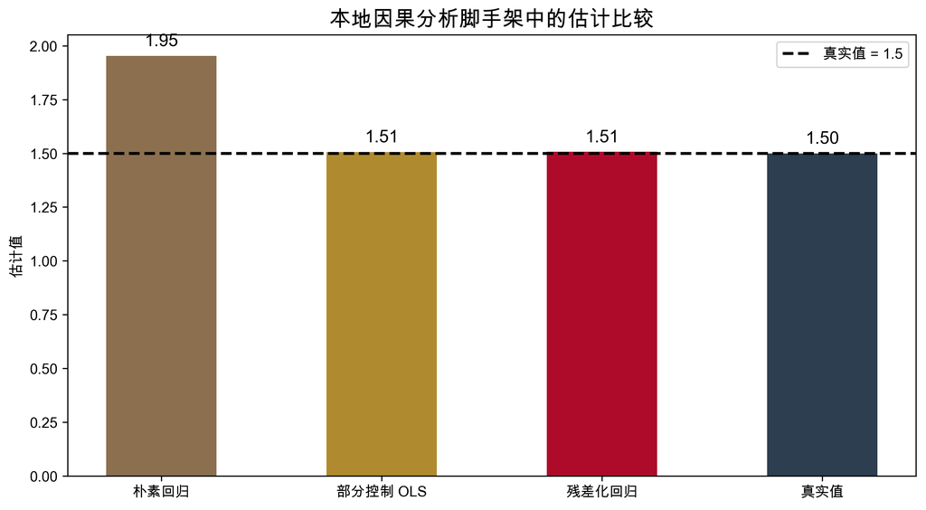

### 3.4.4 方法论上的结论

AI 在这一步的真正价值，不是给你一个神奇新估计器，而是让你更快地：

- 明确输入输出
- 组织可运行代码
- 生成对照组、对比表和可视化
- 把估计阶段接进一个更大的验证循环

## 3.5 写作与复现：AI 最适合产出哪些中间品？

研究完成之后，很多工作仍然耗时：

- 为图表写注释
- 把代码结果转成课堂汇报或论文叙述
- 准备答辩中的反对意见与回复

这是 AI 很适合出力的地方。但一定要使用固定模板，而不是让它自由发挥。例如，一个好的结果解释模板应强制包含：

1. 估计对象是什么
2. 识别依赖什么假设
3. 统计不确定性如何体现
4. 结论只适用于哪些边界条件

如果没有这四项，AI 生成的“流畅解释”很容易沦为相关性包装术。

| 中间品 | AI 可以生成 | 人类要检查 |
| --- | --- | --- |
| **分析计划** | 研究流程、变量字典、检查清单 | 是否遗漏关键假设 |
| **代码脚手架** | 导包、建模模板、作图模板 | 是否存在样本泄漏、错误控制 |
| **报告草稿** | 图表说明、结果摘要、局限性模板 | 是否过度外推、是否把相关当因果 |
| **审稿清单** | 反问式 checklist | 是否覆盖识别、稳健性、外部效度 |

# 4 第三部分：大语言模型的具体应用场景

## 4.1 场景一：文献综述矩阵

研究一开始，学生常常面对几十篇论文摘要，不知道如何快速归纳。AI 在这里最自然的用途，是把摘要整理成研究设计矩阵，而不是“帮你直接写 literature review”。

一个好矩阵至少应包含这些列：

- 研究问题
- 处理变量
- 结果变量
- 数据来源
- 识别策略
- 估计对象
- 主要局限性

这样做的好处是，AI 输出能被快速抽查，也更容易服务于你自己的研究设计比较。

## 4.2 场景二：文本变量构造

因果研究中的文本材料越来越多，例如：

- 政策文件
- 平台公告
- 公司年报
- 访谈纪要
- 新闻标题与用户评论

这些材料往往包含重要机制信息，但不能直接进入回归，需要先变成结构化变量。大语言模型在这一步非常有用，因为它擅长把长文本归类、摘要、提取字段。

不过，一旦你打算把 AI 结构化的文本标签用于因果分析，就必须多加一层验证：字段完整性、标签白名单、一致性抽样检查。

### 4.2.1 Python 演示：结构化输出校验

```python
print(structured_df.to_string(index=False))
```

```
document policy_type timing strength     risk  标签合法
地方补贴政策说明          补贴    处理前        高  政策选择性覆盖  True
  平台治理公告          监管    处理前        中 执行力度地区差异  True
处罚政策访谈纪要          处罚    处理后        低     回忆偏误  True
```

这一步展示的不是“如何调用模型”，而是“拿到结构化输出后如何审查”。如果连标签合法性都没有检查，就把结果直接并入主数据集，后面所有回归都有可能建立在错误测量之上。

### 4.2.2 这一场景的风险

- **标签漂移**：AI 对同一类文本在不同轮次给出不同标签
- **信息泄漏**：不小心把处理后的描述拿来构造处理强度
- **伪精确性**：文本标签看起来很细，但缺乏稳定定义

### 4.2.3 课堂建议

如果使用 LLM 做文本结构化，至少保留：

1. 原始文本样本
2. 提示模板
3. 模型输出 JSON
4. 人工抽样复核记录

## 4.3 场景三：大数据探索与查询协作

在大数据场景里，AI 的最佳定位不是“直接给我答案”，而是“帮助我快速写出第一版查询与聚合草案”。

例如，当数据量很大时，你可以把以下信息交给 AI：

- 表结构和字段释义
- 观测单位
- 时间变量
- 关键聚合指标
- 想要比较的处理组与对照组

然后让它先生成 SQL、DuckDB 或 pandas 查询草案。研究者再在本地执行，并核对：

- join 是否正确
- 聚合层级是否匹配研究问题
- 时间窗口是否发生穿越
- 是否意外过滤掉了关键样本

### 4.3.1 推荐的对话方式

```
下面是表结构、主键、时间字段和指标定义。请不要做结论，先帮我：
1. 写出一版聚合草案
2. 说明每个 group by 和 filter 的目的
3. 提醒我最可能出现的数据泄漏和重复计数风险
```

这种对话方式的价值在于：你让 AI 产出的是 *可检查对象*，而不是不可追踪的“智能答案”。

**警告正确姿势**

不要把大数据直接扔给 LLM，也不要让它在没有架构（schema）的情况下自由发挥。

## 4.4 场景四：调试、审稿与结果解释

当项目进入中后期，AI 往往在这三类任务上最省时间：

1. **代码调试**：定位异常、维度错误、重复 merge、可视化 bug
2. **审稿模拟**：站在 reviewer 视角质疑识别与稳健性
3. **结果解释**：按固定模板生成图注、摘要和答辩用语

但这里也最容易发生一种假象：AI 说得越流畅，研究者越容易以为它理解得越深。事实上，很多时候它只是语言上更像一篇论文，而不是证据上更扎实。

因此，调试和审稿阶段要特别强调“反问式使用”：

- 我最脆弱的识别假设是什么？
- 如果 reviewer 质疑样本选择，我该补什么证据？
- 这张图是否把相关误写成了因果？

**提示纪律**

AI 给的是候选答案，不是最终结论。每一个 AI 建议都要回答四个问题：它替代了什么劳动？可能犯什么错？如何验证？失败后如何回退？

# 5 第四部分：验证、审计与伦理

## 5.1 验证循环

AI 协作之所以能从“花哨工具”变成“研究生产力”，关键不在模型本身，而在是否建立了验证循环。

下面是一条最实用的工作流：

```
flowchart TD
    A[自然语言任务] --> B[AI 生成脚手架]
    B --> C[本地运行]
    C --> D[查看中间结果]
    D --> E[提出反问]
    E --> F[修订代码与假设]
    F --> G[记录版本与日志]
    G --> H[形成可复现结果]
```

[output not shown]

这个循环的本质是：**任何一步都不能直接跳到结论**。你必须看到中间对象，看到失败原因，看到回滚路径。

## 5.2 常见失败模式

AI 在因果研究中最常见的失败模式有六类：

1. **把预测问题伪装成因果问题**
2. **把 post-treatment variables 当作控制变量**
3. **把相关性语言包装成机制语言**
4. **忽略样本选择和数据口径变化**
5. **在文本变量构造中产生不可见测量误差**
6. **生成看似完整、实则无法复现的代码**

### 5.2.1 一个实践清单

在接受任何 AI 输出之前，至少问自己八个问题：

1. 这个输出替代了哪一步劳动？
2. 这一步的成功标准是什么？
3. 有没有时间顺序问题？
4. 有没有样本泄漏？
5. 中间对象是否可见？
6. 是否已经有日志和版本？
7. 如果它错了，我如何定位？
8. 如果它完全不行，我如何回退？

## 5.3 数据安全、版权与合规

在 AI 协作研究中，技术之外还有三类底线问题：

- **隐私**：是否包含可识别个人信息、交易数据、敏感文本
- **版权**：是否把受限制的数据和文档直接上传到不安全环境
- **可追责性**：是否能说明某个结果是怎么得到的

对于课堂项目而言，最稳妥的原则是：

**警告安全第一**

敏感原始数据尽量留在本地；给 AI 的是 schema、脱敏样本、统计摘要和任务描述，而不是完整原始库。

这样做并不会削弱 AI 的协作价值，因为 AI 真正擅长的是理解任务结构和代码框架，而不是必须直接接触全部原始数据。

# 6 第五部分：完整 mini case

## 6.1 一个教学案例：平台补贴与留存

为了把本讲的思想串起来，我们可以把项目 workflow 设计成一个 mini case：

**问题**：平台定向补贴是否提高商家 30 天留存？

这类问题同时具有：

- 典型的政策/平台干预结构
- 明确的处理与结果变量
- 大量潜在混杂
- 可能存在的文本材料（政策公告、商家反馈）

### 6.1.1 第一步：结构化问题

AI 可以帮助你快速整理：

- 处理变量定义
- 结果变量窗口
- 候选混杂
- 可疑的 post-treatment measures
- 需要记录的样本限制

### 6.1.3 第三步：文本变量补充机制解释

如果商家反馈文本中包含对补贴政策的理解与执行情况，那么 AI 可以帮你把这些文本整理成：

- 是否属于政策响应型商家
- 是否提到资金约束
- 是否出现执行摩擦

这些结构化变量未必直接进入主回归，但可以作为机制证据或异质性分析的补充。

### 6.1.4 第四步：形成项目答辩材料

最后，AI 可以帮助你生成：

- 图表说明
- 风险与局限性清单
- 答辩问答草稿
- 可复现实验摘要

但你必须保证每一条叙述都能指回具体代码、图表和结果对象。

# 7 第六部分：课程收官与研究能力升级

## 7.1 AI 时代的研究能力栈

过去，很多人把研究能力理解成两件事：懂理论、会跑回归。今天这已经不够了。你还需要三类新增能力：

1. **工程能力**：把分析流程拆成模块，让 AI 能协作而不失控
2. **验证/评审能力**：快速定位 AI 输出的错误并建立回滚机制
3. **编排能力**：把文献、数据、代码、图表和叙事组织成一个一致系统

换句话说，AI 并没有降低研究门槛，它只是把门槛从“会不会写代码”进一步提高到“能不能驾驭完整 workflow”。

## 7.2 课程收官：项目答辩与研究展示

课程最后的重点，不再是再学一个新工具，而是把整个学期形成的方法论、代码能力和研究表达整合起来，完成一次可信的项目展示。答辩时，最值得展示的不是“我让 AI 帮我写了多少代码”，而是：

- 如何用清晰的识别逻辑讲好你的研究故事
- 如何展示数据、代码、稳健性与 AI 协作日志
- 如何把“会做分析”呈现成“会做研究”

如果你准备把 AI 纳入期末项目，可以按照以下顺序：

1. **先写研究问题与识别草图**
2. **再让 AI 生成数据审计与代码脚手架**
3. **把估计结果、图表和日志纳入版本控制**
4. **保留一页 AI 使用说明**：它做了什么，没有做什么，你如何验证

这会显著提升项目的可信度，也能帮助你在答辩中说清楚“AI 参与”究竟意味着什么。

# 8 总结

本讲最重要的收获，不是多学了一个新工具，而是完成了一次视角转换：

- 从“AI 会不会替我做研究”
- 转向“我如何把 AI 驯化为研究 workflow 的一部分”

只要你始终坚持四件事，AI 就会成为真正的研究助力：

1. 先定义问题，再写提示词
2. 先看中间对象，再谈结论
3. 先建立验证循环，再追求效率
4. 先明确责任边界，再扩大自动化范围

**注记一句话结论**

AI 时代的核心竞争力，不是让模型替你思考，而是让模型帮你更快地提出问题、检查证据，并把正确答案组织成可信研究。

# 9 第七部分：终极问题与哲学追问

## 9.1 科学研究的本质是什么？

如果沿着本讲一路回看，我们其实已经触碰到一个比 workflow 更深的问题：**科学研究到底在做什么？**

最浅的一层回答是，研究是在生产结论；再深一层，是在生产解释；更深一层，是在生产一种可以被别人检验、反驳和继承的公共知识。也就是说，科学研究不是单纯“写出一段看起来合理的话”，而是把一个问题转化为：

1. 可定义的对象
2. 可检验的证据
3. 可复现的过程
4. 可争辩的结论

这也是为什么 AI 虽然能极大提升文本生成、代码搭建和资料整理效率，却并没有因此自动成为“科学本身”。模型可以帮助你生产候选解释，但是否形成知识，取决于它能否进入检验、批评和复现的共同体。

从这个角度看，研究最核心的品质并不是“产出很多”，而是：

- 问了一个真正值得问的问题
- 给出了能够区分真假、优劣、强弱的证据路径
- 愿意让结论暴露在反驳与失败面前

这也是本讲反复强调日志、版本、验证循环的原因。没有这些，AI 只能帮助我们更快地产生文本；有了这些，AI 才可能帮助我们更快地产生知识。

## 9.2 人类的思考是独特的吗？

一旦 AI 能写代码、归纳文献、提出假说，很多人自然会问：**人类的思考到底还有什么独特之处？**

如果把思考理解为模式识别、文本重组和候选答案生成，那么 AI 确实会越来越强，甚至在许多局部任务上已经比人更快、更广、更稳定。但研究中的“思考”并不只包括这些。

至少还有三类能力，今天仍然更接近人的核心角色：

1. **问题选择**：研究什么，从来不只是技术问题，而是价值判断。什么值得投入时间？什么问题真正重要？这涉及制度背景、社会后果与人的处境。
2. **责任承担**：一个结论进入公共讨论、政策制定或商业决策后，若它有误，谁来承担责任？模型不会承担学术伦理和社会后果，人必须承担。
3. **意义建构**：同一组证据可以被写成不同叙事。如何把事实、机制和人的经验连接起来，使知识真正“有意义”，这并不等同于句子通顺或结构完整。

因此，人类思考的独特性，也许不在于永远比机器更聪明，而在于：人类不仅生成答案，还要决定什么问题值得回答，什么代价可以接受，什么结论可以进入世界。

## 9.3 如果 AI 超过人类，对于人类意味着什么？

如果未来 AI 在提出假说、调度工具、运行实验、写作与审稿上都系统性超过大多数人类研究者，那么真正变化的就不只是“谁写得更快”，而是整个知识秩序会如何重组。

第一个变化是：**知识生产会从稀缺变成过剩**。届时真正稀缺的，不再是论文草稿、图表或候选解释，而是对这些产出的筛选、验证、归档和治理能力。

第二个变化是：**研究者的角色会从主要执行者转向提问者、裁决者和编排者**。谁能设定好的目标函数、建立合理的评估标准、把自动化流程约束在可解释与可追责的轨道上，谁就更接近未来的核心研究能力。

第三个变化是：**我们必须重新理解“人类价值”**。如果效率、记忆、检索、组合、写作、乃至局部推理都不再是人的独占优势，那么人的价值可能更多体现在：

- 对何为重要问题的判断
- 对何为可接受风险的判断
- 对制度、伦理与公共后果的判断

换句话说，AI 超过人类，不必然意味着人类失去意义；它更可能迫使我们放弃把“快”和“多”误当成“高价值”的旧观念，转而重新定义研究者为什么存在。

## 9.4 最后的递进结论

把这三个问题连起来，可以形成一个递进链条：

1. **科学研究的本质**不是生成文本，而是生成可检验、可争辩、可继承的知识。
2. **人类思考的独特性**不只在于计算或表达，而在于价值判断、责任承担和意义建构。
3. **AI 超过人类之后**，真正不会被自动化替代的，恰恰是那些决定问题、约束流程、承担后果的能力。

因此，本讲关于 AI workflow 的讨论，最终并不是为了把研究完全自动化，而是为了逼近一个更深的目标：**让自动化越强，人类对问题、证据与责任的把握也必须越强。**

**重要最后的追问**

也许未来最重要的能力，不是比 AI 更快，而是比 AI 更知道什么值得慢下来；不是比 AI 产出更多，而是比 AI 更清楚哪些结论值得相信、哪些判断值得负责。

# 10 练习题

## 10.1 概念题

1. 为什么说 AI 不能替代识别策略？请结合 post-treatment variables 的例子说明。
2. 请用自己的话解释“严谨版 vibe coding”与“随意让 AI 写代码”的区别。
3. 在文献综述、数据审计、估计推断、结果解释四个环节中，哪两个环节最适合 AI 高强度参与？为什么？
4. 为什么“预测准确率高”不等于“因果识别可信”？

## 10.2 编程与 workflow 题

5. 给定一个研究问题，请写出一个高质量提示模板，使 AI 输出：处理变量、结果变量、estimand、候选混杂和需要人工核对的识别风险。
6. 修改本讲的 Python 代码，使其报告每一种估计方法相对于真实值的偏差。
7. 设计一个文本变量结构化流程，要求包含：原文、提示模板、JSON 输出、白名单校验与人工抽样复核。
8. 为你的期末项目设计一页“AI 协作日志”，至少包含：任务、输入上下文、AI 输出、人工修改、验证证据。

# 11 参考文献

1. [GitHub] Assaf Elovic. *GPT Researcher*. https://github.com/assafelovic/gpt-researcher

   该项目把 automated research workflow 具体化为 planner、execution agents、source tracking、report aggregation 与 observability 等模块。它特别适合作为课堂示例，因为它展示了“研究问题分解 -> 多来源抓取 -> 汇总成文”的完整代理化流程，而不只是一个单步问答机器人。
2. [GitHub] Hugging Face. *smolagents*. https://github.com/huggingface/smolagents

   `smolagents` 强调 code agents，也就是让模型把动作写成代码，再通过工具和 sandbox 执行。这与本讲讨论的 vibe coding 和 AI coding workflow 高度相关，因为它体现了“自然语言提出任务，代码作为可检查中间对象”的设计思想。
3. [GitHub] Microsoft Research / community. *AutoGen*. https://github.com/microsoft/autogen

   AutoGen 虽已进入 maintenance mode，但它仍然是多代理 workflow 的代表性框架之一。它提供了 MCP、multi-agent orchestration、AgentChat 和 AutoGen Studio 等示例，适合说明如何把复杂研究任务拆成多个角色并进行编排。
4. [Web] The Turing Way Community. *Guide for Reproducible Research*. https://book.the-turing-way.org/reproducible-research/reproducible-research.html

   The Turing Way 从 reproducibility 的角度系统说明了数据、代码、版本控制、测试和计算环境为什么必须能够“重新跑通”。这与本讲强调的“AI 协作必须留下证据、日志和回滚路径”完全一致，是 automated research workflow 的规范性基础。
5. [Web] Quarto. *Project Basics*. https://quarto.org/docs/projects/quarto-projects.html

   Quarto 的项目文档说明了 `_quarto.yml`、render targets、shared metadata、output-dir 与 freeze 等机制。对本课程而言，这正对应“如何把分析代码、文字说明、图表和输出文档整合成可复现、可发布、可维护的研究资产”。
6. [GitHub] Kehang Zhu et al. *Automated Social Science: Language Models as Scientist and Subjects*. https://github.com/KeHang-Zhu/lm-automated-social-science/tree/main

   该项目展示了如何让 LLM 同时担任“科学家”和“受试主体”：从一个社会互动场景出发，自动生成结构因果模型、运行文本互动实验、清洗输出并进行后续分析。它特别适合补充本讲对社会科学自动化的讨论，因为它把 hypothesis generation、simulation 和 SCM estimation 串成了一个相对完整的实验链条。
7. [Web] Social Catalyst Lab. *Project APE: Autonomous Policy Evaluation*. https://ape.socialcatalystlab.org/

   APE 项目公开展示 AI 端到端生成政策评估论文、自动锦标赛比较与人工反馈机制。按本讲制作时网站公开信息，它已累计展示约 1000 篇 APE 论文和 1.8 万余次 head-to-head matches，并明确提醒这些结果并非同行评审结论。它非常适合用来讨论：自动化研究系统如何通过公开失败、公开比较和持续反馈，逼近可靠性而非假装完美。
8. [GitHub] Sakana AI. *The AI Scientist*. https://github.com/SakanaAI/AI-Scientist

   The AI Scientist 强调从想法生成、实验执行、论文撰写到模型审稿的完整自动科研循环，并提供不同研究模板与 review pipeline。它同时明确警告会执行模型生成代码，建议容器化并要求在论文中披露 AI 使用情况，因此非常适合作为“自动化科学家能力与风险同时上升”的代表性案例。
9. [GitHub] EvoScientist Team. *EvoScientist*. https://github.com/EvoScientist/EvoScientist

   EvoScientist 代表的是 2026 年更偏“多代理、持久记忆、verify loop、human-on-the-loop”的研究代理系统。它把科学 workflow 显式组织为 plan、research、code、analyze、write、verify 等环节，强调研究者从执行者转向编排者与裁决者，正好与本讲最后的哲学追问形成呼应。